# ggplot2 (Swirl)

##### Explanation 2.4.1:

- The result is a 1 by 3 array of plots.
- Note how each is labeled at the top with the factor label (4,f, or r).
- This shows us more detailed information than the histogram.
- We see the relationship between displacement and highway mileage for each of the 3 drive factors.

##### Example 2.4.2:

- call **qplot** with 4 arguments.
  - This time, since we need **only one variable for a histogram**,
    - the **first is hwy** and
  - the **second is the argument data**
    - **data = mpg**.
  - The **third is the argument facets**
    - which we’ll set equal to the expression **drv ~ .**
    - This will give us a different arrangement of the facets.
  - The **fourth argument is binwidth**.
    - **binwidth = 2**

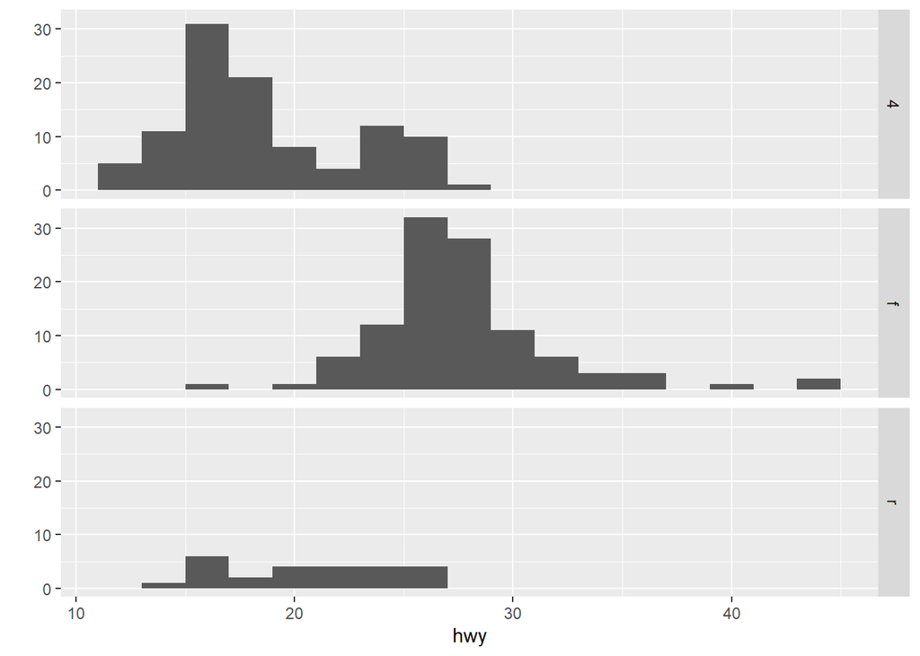

```r
qplot(hwy,data=mpg, facets = drv~.,binwidth=2)
```

##### Explanation 2.4.1:

- The facets argument, **( drv ~ . )**,
  - resulted in a **3 by 1** arrangement of facets

## 3. ggplot

A “grammar” of graphics means that ggplot2 contains building blocks with which you can create your own graphical objects.

There are **7 basic components of ggplot2 plots**:

1. **DATA FRAME**
   - which contains **the data you’re trying to plot**.
2. **AESTHETIC MAPPINGS**
   - determine **how data are mapped to color, size, etc**.
3. **GEOMS** (geometric objects)
   - these are **what you see in the plot (points, lines, shapes)**
4. **FACETS**
   - which are **the panels used in conditional plots**.
5. **STATS**
   - these are **statistical transformations such as binning, quantiles, and smoothing** which ggplot2 applies to the data.
6. **SCALES**
   - It shows **what coding an aesthetic map uses**
   - (for example, male = red, female = blue).
7. **COORDINATE SYSTEM**
   - the **plots are depicted on a COORDINATE SYSTEM**.
   - When you use qplot these were taken care of for you.

### 3.1 Creating ‘g’ (graphical object)

##### Example 3.1.1:

- First create a variable **g** by assigning to it the output of a **call to ggplot with 2 arguments**.
  - The **first is mpg**
    - (our **dataset**) and
  - the **second will tell ggplot what we want to plot**,
    - in this case, **displ and hwy**.
    - These are what we want our aesthetics to represent so we **enclose these as two arguments to the function aes**.

```r
g <- ggplot(mpg,aes(displ,hwy))
```

##### Explanation 3.1.1:

- Notice that nothing happened
- As in the lattice system, ggplot created a graphical object which we assigned to the variable g.

#### Summary of ‘g’

```r
summary(g)
```

```
## data: X, manufacturer, model, displ, year, cyl, trans, drv, cty, hwy,
##   fl, class [234x12]
## mapping:  x = ~displ, y = ~hwy
## faceting: <ggproto object: Class FacetNull, Facet, gg>
##     compute_layout: function
##     draw_back: function
##     draw_front: function
##     draw_labels: function
##     draw_panels: function
##     finish_data: function
##     init_scales: function
##     map_data: function
##     params: list
##     setup_data: function
##     setup_params: function
##     shrink: TRUE
##     train_scales: function
##     vars: function
##     super:  <ggproto object: Class FacetNull, Facet, gg>
```

#### printing problem of ‘g’

```r
print(g)
```

**Note that if you tried to print g with the expressions g or print(g) you’d get an error!**

- Even though it’s a great package, ggplot doesn’t know how to display the data yet since you didn’t specify how you wanted to see it.

### 3.2 g + function() + …

#### 3.2.1 geom_point()

```r
# Prining of 'g'

g+geom_point()
```

[output not shown]

##### Explanation:

- By calling the function geom_point you added a layer.
- By not assigning the expression to a variable you displayed a plot.
- Notice that you didn’t have to pass any arguments to the function geom_point.
  - That’s because the object g has all the data stored in it.

```r
# Prining of 'g'

g+geom_point()
```

[output not shown]

##### Explanation:

- By calling the function geom_point you added a layer.
- By not assigning the expression to a variable you displayed a plot.
- Notice that you didn’t have to pass any arguments to the function geom_point.
  - That’s because the object g has all the data stored in it.

## 3. ggplot

A “grammar” of graphics means that ggplot2 contains building blocks with which you can create your own graphical objects.

There are **7 basic components of ggplot2 plots**:

1. **DATA FRAME**
   - which contains **the data you’re trying to plot**.
2. **AESTHETIC MAPPINGS**
   - determine **how data are mapped to color, size, etc**.
3. **GEOMS** (geometric objects)
   - these are **what you see in the plot (points, lines, shapes)**
4. **FACETS**
   - which are **the panels used in conditional plots**.
5. **STATS**
   - these are **statistical transformations such as binning, quantiles, and smoothing** which ggplot2 applies to the data.
6. **SCALES**
   - It shows **what coding an aesthetic map uses**
   - (for example, male = red, female = blue).
7. **COORDINATE SYSTEM**
   - the **plots are depicted on a COORDINATE SYSTEM**.
   - When you use qplot these were taken care of for you.

```r
library(ggplot2)
```

### 3.1 Creating ‘g’ (graphical object)

- First create a variable **g** by assigning to it the output of a **call to ggplot with 2 arguments**.
  - The **first is mpg**
    - (our **dataset**) and
  - the **second will tell ggplot what we want to plot**,
    - in this case, **displ and hwy**.
    - These are what we want our aesthetics to represent so we **enclose these as two arguments to the function aes**.

```r
g <- ggplot(mpg,aes(displ,hwy))
```

##### Explanation 3.1.1:

- Notice that nothing happened
- As in the lattice system, ggplot created a graphical object which we assigned to the variable g.

#### Summary of ‘g’

```r
summary(g)
```

```
## data: X, manufacturer, model, displ, year, cyl, trans, drv, cty, hwy,
##   fl, class [234x12]
## mapping:  x = ~displ, y = ~hwy
## faceting: <ggproto object: Class FacetNull, Facet, gg>
##     compute_layout: function
##     draw_back: function
##     draw_front: function
##     draw_labels: function
##     draw_panels: function
##     finish_data: function
##     init_scales: function
##     map_data: function
##     params: list
##     setup_data: function
##     setup_params: function
##     shrink: TRUE
##     train_scales: function
##     vars: function
##     super:  <ggproto object: Class FacetNull, Facet, gg>
```

#### printing problem of ‘g’

```r
print(g)
```

**Note that if you tried to print g with the expressions g or print(g) you’d get an error!**

- Even though it’s a great package, ggplot doesn’t know how to display the data yet since you didn’t specify how you wanted to see it.